# MiDAS course: Hands on - part 2

Marie Rissgaard-Jensen

2026-06-11, Aalborg, Denmark

# Questions for the MiDAS course - ampvis hands on part 2.

### Load the packages

```r
library(ampvis2)
library(tidyverse)
library(patchwork) ## Combine different plot using '+'
library(vegan) ## To calculate distance matrix between samples
```

### Set your working directory - only if you did not open script from the downloaded folder

```r
setwd("C:/Users/HD95LP/Downloads/output/MiDAS course - hands on part 2")
WD = "C:/Users/HD95LP/Downloads/output/MiDAS course - hands on part 2/"
```

# Details about the pipelines

**ASV based:** Pipeline: https://github.com/KasperSkytte/snakemake_usearch

**Alignment based (95% identity)** Pipeline: https://github.com/cmc-aau/nanopore_16Samp

## Load the data into an ampvis object

- Remember to adjust paths

```r
metadata <- read.csv(paste0(WD, "metadata.csv")) %>%
  mutate(SampleID = Barcode) %>% relocate(SampleID) %>%
  mutate(PlantID = case_when(LibID == "PCR pos" ~ "PCR pos",
                             LibID == "PCR neg" ~ "PCR neg", .default = PlantID
                             ))

# Alignment based (minimap min identity 95%)
## Raw read (in counts)
d_alignment_raw <- amp_load(otutable = paste0(WD, "Alignment-based/alignment_otutable_mappedreads.tsv"),
              metadata = metadata)
## Normalised data (in percentage: with relative abundances are calculated taking non-mapped reads into account)
d_alignment_norm <- amp_load(otutable = paste0(WD, "Alignment-based/alignment_otutable_normalised.tsv"),
              metadata = metadata)

## Summary file
summary_reads_align <- vroom::vroom(paste0(WD, "Alignment-based/alignment_summary.txt"), show_col_types = F)

# ASV based
d_ASV <- amp_load(otutable = paste0(WD, "ASV-based/ASV_abund_table.tsv"),
              taxonomy = paste0(WD, "ASV-based/ASV_zOTUs.sintax"),
              metadata = metadata
              )
# Total reads
summary_reads_ASV <- read.csv(paste0(WD, "ASV-based/ASV_totalreads.csv"), header = F, col.names = c("SampleID", "total_reads"))
```

# QC

### Ordination

```
## 3748 OTUs not present in more than 0.1% relative abundance in any sample have been filtered
## Before: 4471 OTUs
## After: 723 OTUs
```

```
## 37896 OTUs not present in more than 0.1% relative abundance in any sample have been filtered
## Before: 38414 OTUs
## After: 518 OTUs
```

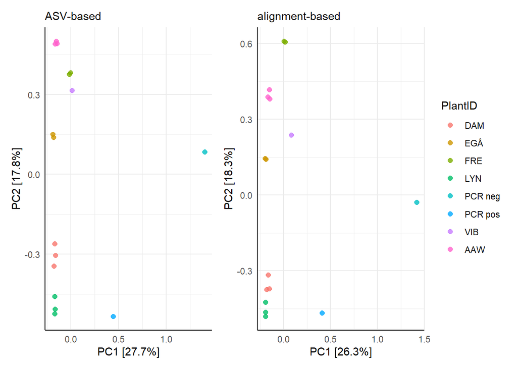

```r
amp_ordinate(d_ASV, sample_color_by = "PlantID") +
        labs(subtitle = "ASV-based") +
  amp_ordinate(d_alignment_norm, sample_color_by = "PlantID") +
          labs(subtitle = "alignment-based")  +
  plot_layout(guides = "collect")
```

### Ordination - no control

```
## 2 samples and 92 OTUs have been filtered
## Before: 16 samples and 4471 OTUs
## After: 14 samples and 4379 OTUs
```

```
## 3784 OTUs not present in more than 0.1% relative abundance in any sample have been filtered
## Before: 4379 OTUs
## After: 595 OTUs
```

```
## 2 samples and 2115 OTUs have been filtered
## Before: 16 samples and 38414 OTUs
## After: 14 samples and 36299 OTUs
```

```
## 35825 OTUs not present in more than 0.1% relative abundance in any sample have been filtered
## Before: 36299 OTUs
## After: 474 OTUs
```

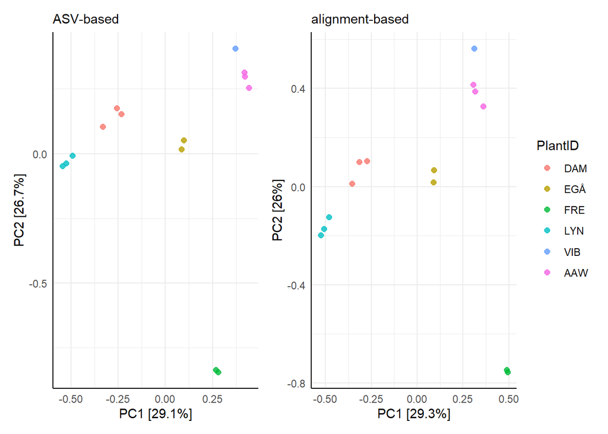

```r
amp_ordinate(d_ASV %>% amp_subset_samples(!str_detect(PlantID,  "PCR")), sample_color_by = "PlantID") +
        labs(subtitle = "ASV-based") +
  amp_ordinate(d_alignment_norm %>% amp_subset_samples(!str_detect(PlantID,  "PCR")), sample_color_by = "PlantID") +
          labs(subtitle = "alignment-based") +
  plot_layout(guides = "collect")
```

### Rarefaction

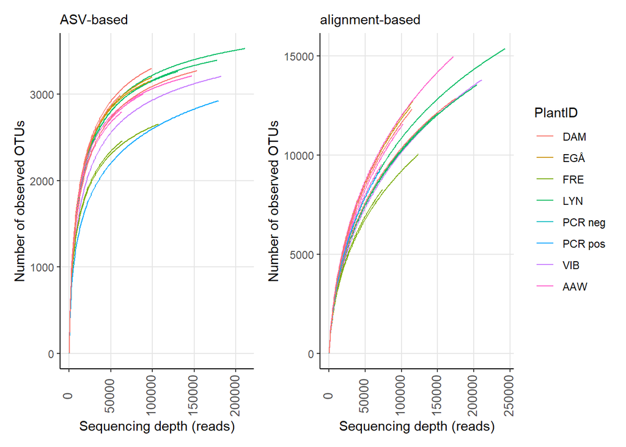

```r
amp_rarecurve(d_ASV, color_by =  "PlantID") +
      labs(subtitle = "ASV-based") +
  amp_rarecurve(d_alignment_raw, color_by = "PlantID") +
        labs(subtitle = "alignment-based")  +
  plot_layout(guides = "collect")
```

# Questions:

Explain and/or make plots in order to answer the questions

- What are the main difference between the datasets?
- How are unclassified reads treated?
- How many reads are unmapped in the two datasets? What do these represent?
- Calculate alpha diversity indexes - what do they tell. What is the importance of rarefaction
- How many distinct ASVs/Species/Genus/.. are present for each dataset - how many are shared? What is the effect of adding an abundance cutoff?
- What are the most abundant taxa - does if differ depending on taxonomic level?
- Consider how to merge dataset to visualize betadiversity
- At which taxonomic level would you trust the datasets? Why?

# How are unclassified reads treated?

**ASV-based**: Novelty is clustered into ASVs without any classification

**Alignment-based**: No match: the read will be put into a single unclassified group

### Unclassified when using an ASV based approch

```r
d_ASV$tax %>%
  mutate(Order = if_else(Order == "", " Unclassified", Order)) %>%
  arrange((Order)) %>% head()
```

```
##              Kingdom              Phylum             Class         Order
## Zotu3368 k__Bacteria p__Actinobacteriota c__Actinobacteria  Unclassified
## Zotu4332 k__Bacteria                                        Unclassified
## Zotu1361 k__Bacteria p__Bdellovibrionota    c__Oligoflexia  o__0319-6G20
## Zotu2439 k__Bacteria p__Bdellovibrionota    c__Oligoflexia  o__0319-6G20
## Zotu2534 k__Bacteria p__Bdellovibrionota    c__Oligoflexia  o__0319-6G20
## Zotu2781 k__Bacteria p__Bdellovibrionota    c__Oligoflexia  o__0319-6G20
##                   Family           Genus          Species      OTU
## Zotu3368                                                  Zotu3368
## Zotu4332                                                  Zotu4332
## Zotu1361 f__midas_f_3092 g__midas_g_4458  s__midas_s_7751 Zotu1361
## Zotu2439 f__midas_f_2887 g__midas_g_2887 s__midas_s_26354 Zotu2439
## Zotu2534 f__midas_f_3092 g__midas_g_4458  s__midas_s_4458 Zotu2534
## Zotu2781 f__midas_f_3092 g__midas_g_3697  s__midas_s_3697 Zotu2781
```

```r
d_ASV$tax %>%
  mutate(Family = if_else(Family == "", " Unclassified", Order)) %>%
  arrange((Family)) %>% head(n = 10)
```

```
##              Kingdom              Phylum                  Class
## Zotu149  k__Bacteria   p__Proteobacteria c__Alphaproteobacteria
## Zotu729  k__Bacteria p__Actinobacteriota      c__Actinobacteria
## Zotu1355 k__Bacteria      p__Chloroflexi        c__Anaerolineae
## Zotu1459 k__Bacteria  p__Patescibacteria     c__Saccharimonadia
## Zotu2432 k__Bacteria  p__Patescibacteria     c__Saccharimonadia
## Zotu3265 k__Bacteria p__Actinobacteriota      c__Acidimicrobiia
## Zotu3368 k__Bacteria p__Actinobacteriota      c__Actinobacteria
## Zotu3979 k__Bacteria  p__Patescibacteria     c__Saccharimonadia
## Zotu4332 k__Bacteria
## Zotu4390 k__Bacteria  p__Patescibacteria     c__Saccharimonadia
##                         Order        Family Genus Species      OTU
## Zotu149        o__Rhizobiales  Unclassified                Zotu149
## Zotu729          o__midas_o_5  Unclassified                Zotu729
## Zotu1355          o__C10-SB1A  Unclassified               Zotu1355
## Zotu1459 o__Saccharimonadales  Unclassified               Zotu1459
## Zotu2432 o__Saccharimonadales  Unclassified               Zotu2432
## Zotu3265    o__Microtrichales  Unclassified               Zotu3265
## Zotu3368                       Unclassified               Zotu3368
## Zotu3979 o__Saccharimonadales  Unclassified               Zotu3979
## Zotu4332                       Unclassified               Zotu4332
## Zotu4390 o__Saccharimonadales  Unclassified               Zotu4390
```

```r
d_ASV$tax %>%
  mutate(Genus = if_else(Genus == "", " Unclassified", Order)) %>%
  arrange((Genus)) %>% head(n = 10)
```

```
##             Kingdom              Phylum                  Class
## Zotu45  k__Bacteria   p__Proteobacteria c__Alphaproteobacteria
## Zotu88  k__Bacteria   p__Proteobacteria c__Alphaproteobacteria
## Zotu96  k__Bacteria   p__Proteobacteria c__Alphaproteobacteria
## Zotu104 k__Bacteria     p__Bacteroidota         c__Bacteroidia
## Zotu139 k__Bacteria   p__Proteobacteria c__Alphaproteobacteria
## Zotu140 k__Bacteria     p__Bacteroidota         c__Bacteroidia
## Zotu146 k__Bacteria p__Actinobacteriota      c__Actinobacteria
## Zotu148 k__Bacteria     p__Bacteroidota         c__Bacteroidia
## Zotu149 k__Bacteria   p__Proteobacteria c__Alphaproteobacteria
## Zotu150 k__Bacteria      p__Chloroflexi        c__Anaerolineae
##                         Order                Family         Genus Species
## Zotu45         o__Rhizobiales  f__Xanthobacteraceae  Unclassified
## Zotu88     o__Rhodobacterales   f__Rhodobacteraceae  Unclassified
## Zotu96    o__Sphingomonadales  f__Sphingomonadaceae  Unclassified
## Zotu104    o__Chitinophagales     f__Saprospiraceae  Unclassified
## Zotu139    o__Rhodobacterales   f__Rhodobacteraceae  Unclassified
## Zotu140    o__Chitinophagales     f__Saprospiraceae  Unclassified
## Zotu146      o__Micrococcales f__Intrasporangiaceae  Unclassified
## Zotu148 o__Sphingobacteriales  f__Lentimicrobiaceae  Unclassified
## Zotu149        o__Rhizobiales                        Unclassified
## Zotu150      o__Caldilineales     f__Caldilineaceae  Unclassified
##             OTU
## Zotu45   Zotu45
## Zotu88   Zotu88
## Zotu96   Zotu96
## Zotu104 Zotu104
## Zotu139 Zotu139
## Zotu140 Zotu140
## Zotu146 Zotu146
## Zotu148 Zotu148
## Zotu149 Zotu149
## Zotu150 Zotu150
```

### Summary of read/abundance in the ampvis object

```r
d_alignment_norm$abund %>% colSums()
```

```
## barcode01 barcode13 barcode25 barcode37 barcode49 barcode61 barcode73 barcode85
##   92.1738   92.6547   92.4107   93.8081   92.7795   93.2586   92.7215   92.1329
## barcode02 barcode14 barcode26 barcode38 barcode50 barcode62 barcode74 barcode86
##   92.2958   92.9107   94.0355   93.7948   93.3797   93.6068   30.7649   93.9393
```

```r
d_alignment_raw$abund %>% colSums()
```

```
## barcode01 barcode13 barcode25 barcode37 barcode49 barcode61 barcode73 barcode85
##    243301    204456    150532    123058     73968     70137    175156    114478
## barcode02 barcode14 barcode26 barcode38 barcode50 barcode62 barcode74 barcode86
##    211100    115594    112189    102067    171522     72511     70138        31
```

```r
## ASV based
d_ASV$abund %>% colSums()
```

```
## barcode01 barcode13 barcode25 barcode37 barcode49 barcode61 barcode73 barcode85
##    210953    177551    130577    107203     63535     61089    153330     98815
## barcode02 barcode14 barcode26 barcode38 barcode50 barcode62 barcode74 barcode86
##    182311     99159     97607     88725    147540     63173    179385        26
```

```r
amp_subset_samples(d_ASV, normalise = T)[[1]] %>% colSums()
```

```
## 0 samples have been filtered.
```

```
## barcode01 barcode13 barcode25 barcode37 barcode49 barcode61 barcode73 barcode85
##       100       100       100       100       100       100       100       100
## barcode02 barcode14 barcode26 barcode38 barcode50 barcode62 barcode74 barcode86
##       100       100       100       100       100       100       100       100
```

# How many reads are unmapped in the two datasets? What do these represent?

```r
merged_alpha_div <-
  rbind(
    d_alignment_raw %>% amp_alpha_diversity() %>% mutate(type = "alignment") %>%
      left_join(summary_reads_align %>% select(barcode, total_filtered_reads) %>%
                  rename("SampleID" = "barcode",
                         "total_reads" = "total_filtered_reads"), by = join_by(SampleID)),
    d_ASV %>% amp_alpha_diversity() %>% mutate(type = "ASV") %>%
      left_join(summary_reads_ASV, by = join_by(SampleID)))
```

### Mapped read summery

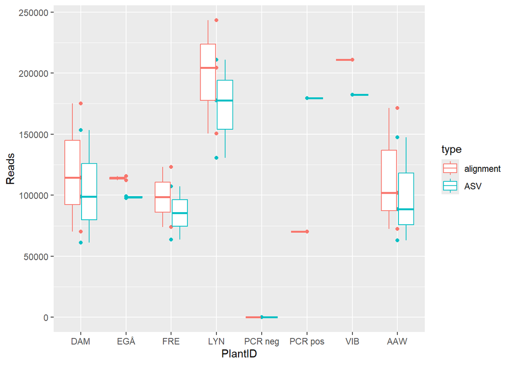

```r
merged_alpha_div %>%
ggplot(
    aes(x = PlantID, y = Reads, colour = type)
  ) +
    geom_point(aes(group = type)) +
  geom_boxplot()
```

### Total and mapped reads summery

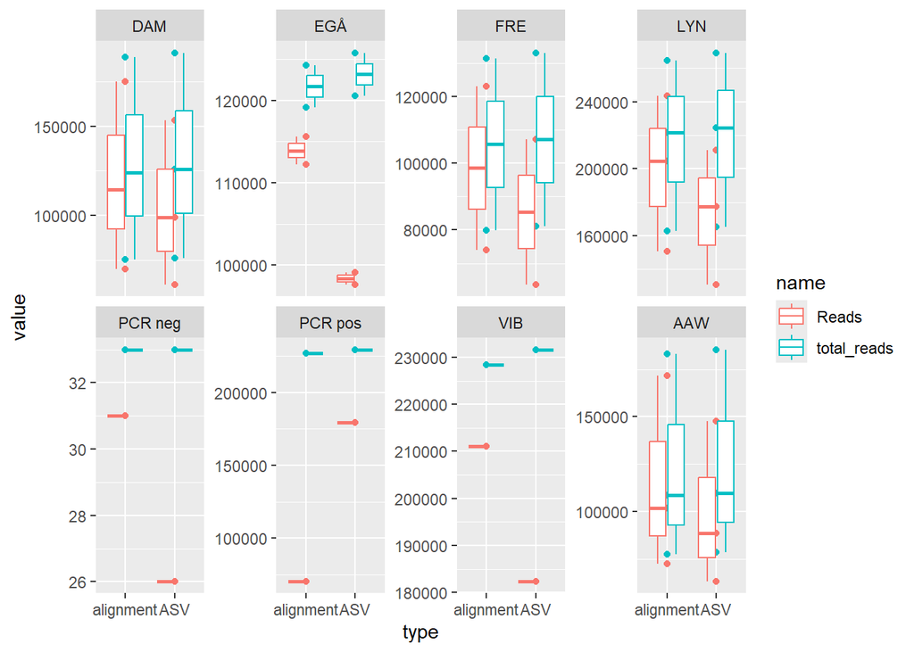

```r
merged_alpha_div %>%
    pivot_longer(cols = c(total_reads, Reads)) %>%
  ggplot(
    aes(x = type, y = value, colour = name)
  ) +
    geom_point() +
  geom_boxplot() +
    #labs(subtitle = "Rarefied 70137 reads") +
    facet_wrap(~PlantID, scales = "free_y", nrow = 2)
```

### Percent mapped reads

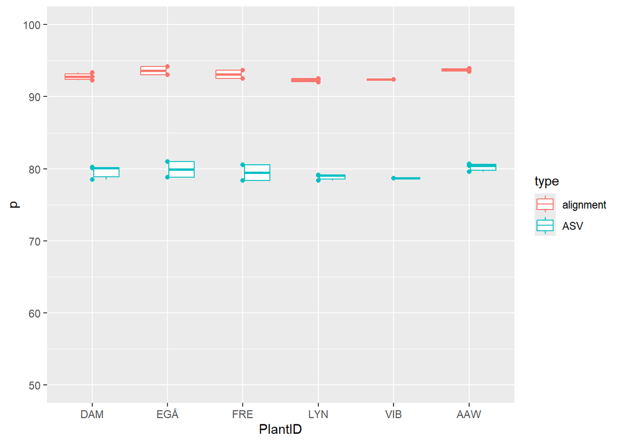

```r
merged_alpha_div %>%
    filter(!str_detect(PlantID,  "PCR")) %>%
  mutate(p = Reads/total_reads*100) %>%
    pivot_longer(cols = c(total_reads, Reads)) %>%
  ggplot(
    aes(x = PlantID, y = p, colour = type)
  ) +
    geom_point() +
  scale_y_continuous(limits = c(50,100)) +
  geom_boxplot() #+
```

```r
    #labs(subtitle = "Rarefied 70137 reads") +
    facet_wrap(~PlantID, scales = "free_y")
```

```
## <ggproto object: Class FacetWrap, Facet, gg>
##     compute_layout: function
##     draw_back: function
##     draw_front: function
##     draw_labels: function
##     draw_panels: function
##     finish_data: function
##     init_scales: function
##     map_data: function
##     params: list
##     setup_data: function
##     setup_params: function
##     shrink: TRUE
##     train_scales: function
##     vars: function
##     super:  <ggproto object: Class FacetWrap, Facet, gg>
```

## Calculate alpha diversity indexes - what do they tell. What is the importance of rarefaction

### Visualise differnet indexes

```r
merged_alpha_div_rare <-
  rbind(
  d_alignment_raw %>% amp_subset_samples(minreads = 70137, rarefy = 70137) %>%
      amp_alpha_diversity() %>% mutate(type = "alignment") %>%
      left_join(summary_reads_align %>% select(barcode, total_filtered_reads) %>%
                  rename("SampleID" = "barcode",
                         "total_reads" = "total_filtered_reads")),
  d_ASV %>% amp_subset_samples(minreads = 70137, rarefy = 70137) %>%
    amp_alpha_diversity() %>% mutate(type = "ASV") %>%
      left_join(summary_reads_ASV))
```

```
## 1 samples and 4775 OTUs have been filtered
## Before: 16 samples and 38414 OTUs
## After: 15 samples and 33639 OTUs
```

```
## 4 samples and 2 OTUs have been filtered
## Before: 16 samples and 4471 OTUs
## After: 12 samples and 4469 OTUs
```

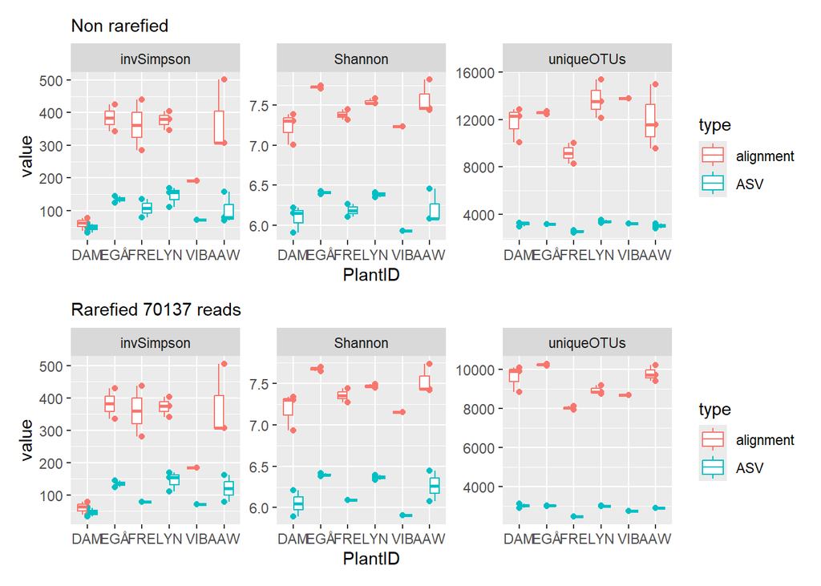

```r
merged_alpha_div %>%
    filter(!str_detect(PlantID,  "PCR")) %>%
  pivot_longer(cols = c(invSimpson , uniqueOTUs,  Shannon)) %>%
  ggplot(
    aes(x = PlantID, y = value, colour = type)
  ) +
    geom_point() +
  geom_boxplot() +
  labs(subtitle = "Non rarefied") +
    facet_wrap(~name, scales = "free_y") +
merged_alpha_div_rare %>%
  select(-Simpson) %>%
    filter(!str_detect(PlantID,  "PCR")) %>%
  pivot_longer(cols = c(invSimpson , uniqueOTUs,  Shannon)) %>%
  ggplot(
    aes(x = PlantID, y = value, colour = type)
  ) +
    geom_point() +
  geom_boxplot() +
    labs(subtitle = "Rarefied 70137 reads") +
    facet_wrap(~name, scales = "free_y") +
  plot_layout(nrow = 2)
```

### Octave plots

Generates an octave plot to assess alpha diversity. An octave plot is a histogram of the number of taxa observed by bins of read counts, where the bin ranges increase exponentially, see details.

```r
amp_octave(d_ASV,
           group_by = "PlantID",
            tax_aggregate = "Species"
           )
```

```
## 1073 OTUs (out of 4471) with no assigned taxonomy at Species level were removed before aggregating OTUs
```

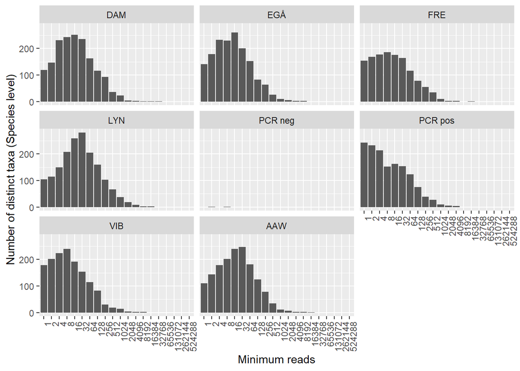

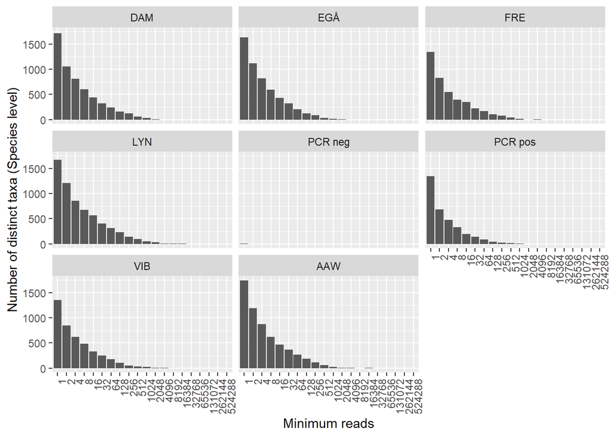

```r
amp_octave(d_alignment_raw,
                      group_by = "PlantID",
           tax_aggregate = "Species" ,
           #tax_aggregate = "Genus"
           )
```

# How many distinct ASVs/Species/Genus/.. are present for each dataset - how many are shared? What is the effect of adding an abundance cutoff?

```r
long_data_merged <- rbind(
  amp_export_long(d_alignment_norm) %>% mutate(type = "alignment"),
  amp_export_long(amp_subset_samples(d_ASV, normalise = T)) %>% mutate(type = "ASV")) %>%
  as_tibble() %>%
    filter(!str_detect(PlantID,  "PCR"))
```

```
## 0 samples have been filtered.
```

## Number of taxa (with abundance filte)

### No filter

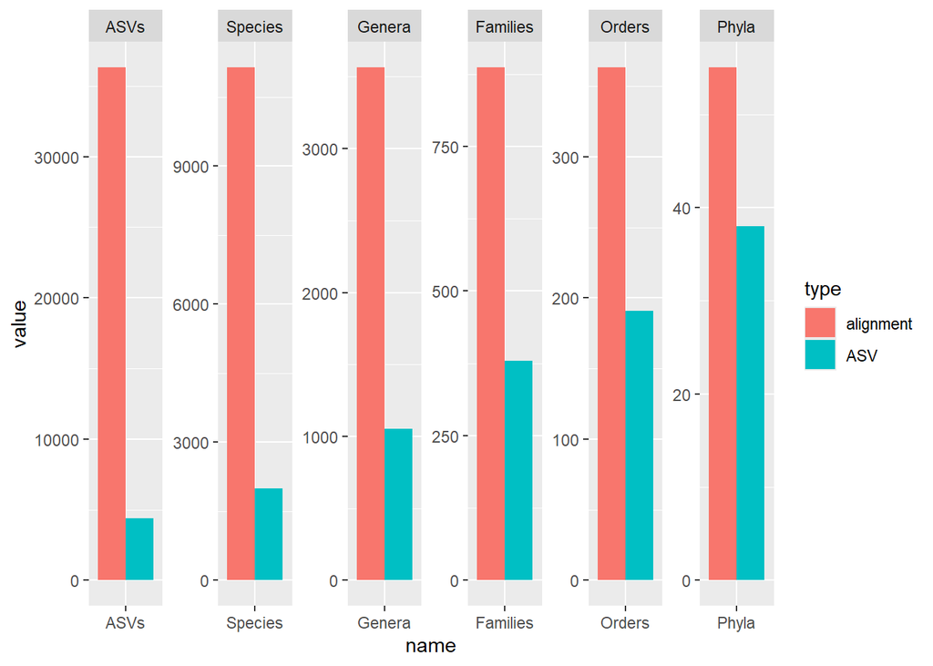

```r
long_data_merged %>%
  filter(count > 0) %>%  ## <---  CHANGE FILTER
  group_by(type) %>%
  summarise(
    ASVs = n_distinct(OTU),
    Species = n_distinct(Species),
    Genera = n_distinct(Genus),
    Families = n_distinct(Family),
    Orders = n_distinct(Order),
    Phyla = n_distinct(Phylum)
  ) %>%
  pivot_longer(cols = -c(type)) %>%
  mutate(name = factor(name, levels = c("ASVs", "Species", "Genera", "Families", "Orders", "Phyla"))) %>%
  ggplot(aes(x = name, y = value, fill = type)) +
  geom_col(position = "dodge") +
  facet_wrap(~name, scales = "free", nrow = 1)
```

### 0.01

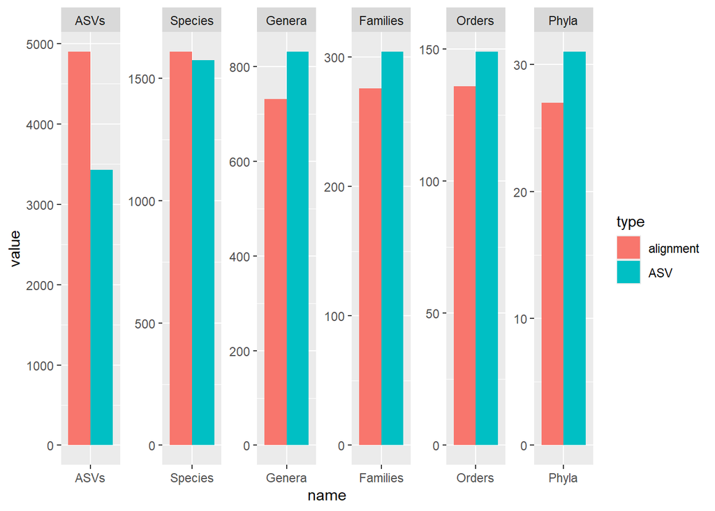

```r
long_data_merged %>%
  filter(count > 0.01) %>%  ## <---  CHANGE FILTER
  group_by(type) %>%
  summarise(
    ASVs = n_distinct(OTU),
    Species = n_distinct(Species),
    Genera = n_distinct(Genus),
    Families = n_distinct(Family),
    Orders = n_distinct(Order),
    Phyla = n_distinct(Phylum)
  ) %>%
  pivot_longer(cols = -c(type)) %>%
  mutate(name = factor(name, levels = c("ASVs", "Species", "Genera", "Families", "Orders", "Phyla"))) %>%
  ggplot(aes(x = name, y = value, fill = type)) +
  geom_col(position = "dodge") +
  facet_wrap(~name, scales = "free", nrow = 1)
```

### 0.1

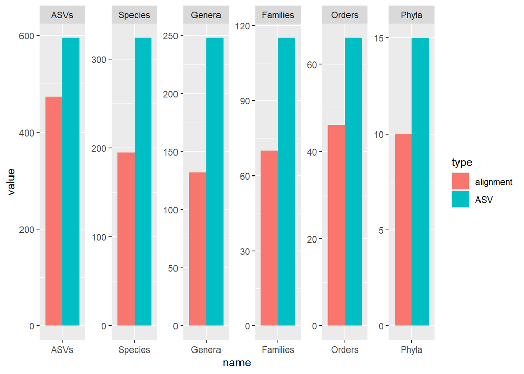

```r
long_data_merged %>%
  filter(count > 0.1) %>%  ## <---  CHANGE FILTER
  group_by(type) %>%
  summarise(
    ASVs = n_distinct(OTU),
    Species = n_distinct(Species),
    Genera = n_distinct(Genus),
    Families = n_distinct(Family),
    Orders = n_distinct(Order),
    Phyla = n_distinct(Phylum)
  ) %>%
  pivot_longer(cols = -c(type)) %>%
  mutate(name = factor(name, levels = c("ASVs", "Species", "Genera", "Families", "Orders", "Phyla"))) %>%
  ggplot(aes(x = name, y = value, fill = type)) +
  geom_col(position = "dodge") +
  facet_wrap(~name, scales = "free", nrow = 1)
```

## Number of shared taxa (with abundance filte)

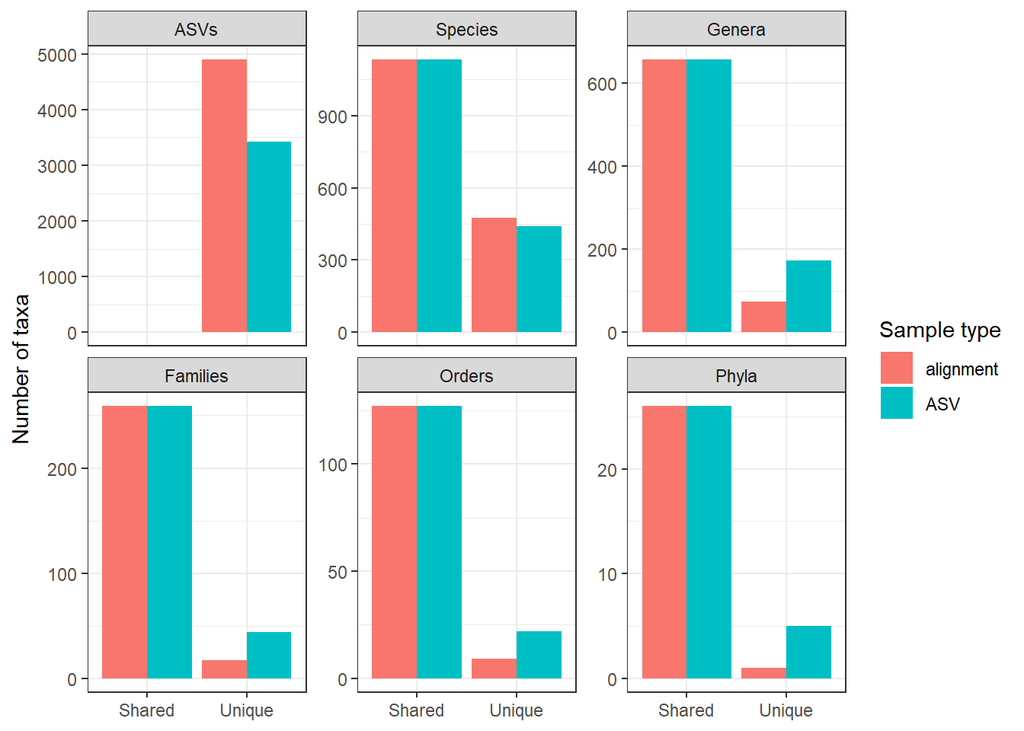

```r
shared_unique_taxa <- long_data_merged %>%
  filter(count > 0.01) %>%                 ## <---  CHANGE FILTER
  select(type, OTU, Species, Genus, Family, Order, Phylum) %>%
  pivot_longer(
    cols = c(OTU, Species, Genus, Family, Order, Phylum),
    names_to = "tax_level",
    values_to = "taxon"
  ) %>%
  filter(!is.na(taxon), taxon != "") %>%
  distinct(tax_level, taxon, type) %>%
  group_by(tax_level, taxon) %>%
  mutate(
    n_types = n_distinct(type),
    status = if_else(n_types == 1, "Unique", "Shared")
  ) %>%
  ungroup()


shared_unique_taxa %>%
  count(type, tax_level, status, name = "n_taxa") %>%
  mutate(
    tax_level = factor(
      tax_level,
      levels = c("OTU", "Species", "Genus", "Family", "Order", "Phylum"),
      labels = c("ASVs", "Species", "Genera", "Families", "Orders", "Phyla")
    )
  ) %>%
  ggplot(aes(x = status, y = n_taxa, fill = type)) +
  geom_col(position = "dodge") +
  facet_wrap(~tax_level, scales = "free_y", nrow = 2) +
  labs(
    x = NULL,
    y = "Number of taxa",
    fill = "Sample type"
  ) +
  theme_bw()
```

# What are the most abundant taxa - does if differ depending on taxonomic level?

## Species

```
## 2 samples and 92 OTUs have been filtered
## Before: 16 samples and 4471 OTUs
## After: 14 samples and 4379 OTUs
```

```
## 2 samples and 2115 OTUs have been filtered
## Before: 16 samples and 38414 OTUs
## After: 14 samples and 36299 OTUs
```

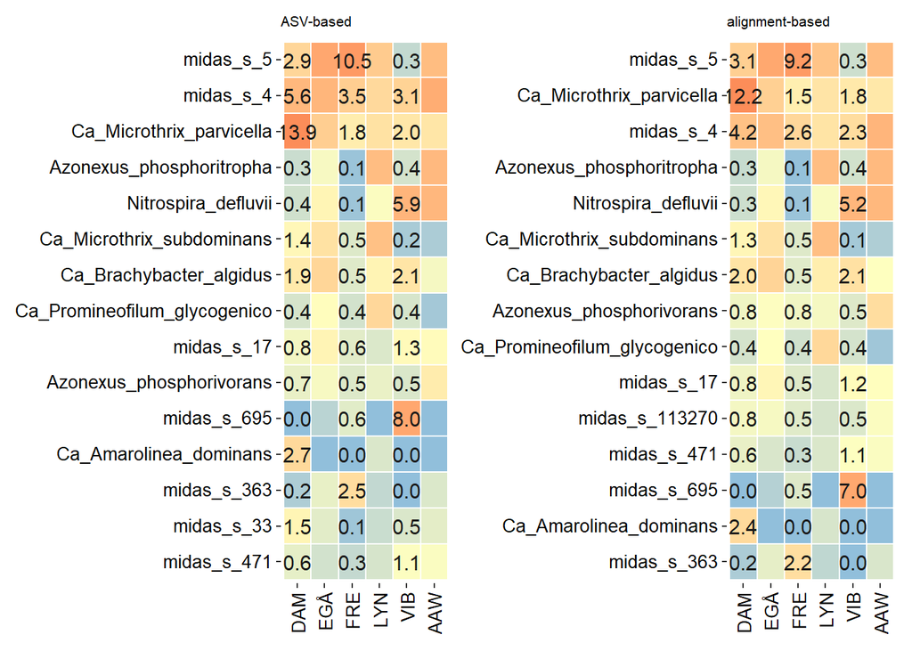

```r
amp_heatmap(d_ASV %>% amp_subset_samples(!str_detect(PlantID,  "PCR")),
            group_by = "PlantID",
            normalise = T,
            tax_show = 15,
            tax_aggregate = "Species")+
      labs(subtitle = "ASV-based") +   theme(axis.text.y = element_text(size = 10)) +
  amp_heatmap(d_alignment_norm %>% amp_subset_samples(!str_detect(PlantID,  "PCR")),
                 group_by = "PlantID",
              normalise = F,
              tax_show = 15,
              tax_aggregate = "Species") +
        labs(subtitle = "alignment-based")  + theme(axis.text.y = element_text(size = 10))
```

## Genus

```
## 2 samples and 92 OTUs have been filtered
## Before: 16 samples and 4471 OTUs
## After: 14 samples and 4379 OTUs
```

```
## 2 samples and 2115 OTUs have been filtered
## Before: 16 samples and 38414 OTUs
## After: 14 samples and 36299 OTUs
```

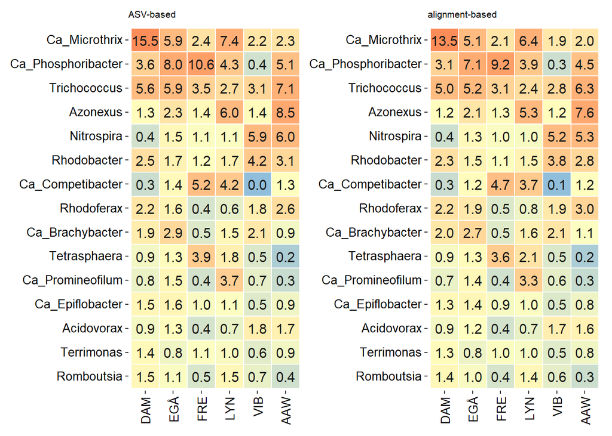

```r
amp_heatmap(d_ASV %>% amp_subset_samples(!str_detect(PlantID,  "PCR")),
            group_by = "PlantID",
            normalise = T,
            tax_show = 15,
            tax_aggregate = "Genus")+
      labs(subtitle = "ASV-based") +   theme(axis.text.y = element_text(size = 10)) +
  amp_heatmap(d_alignment_norm %>% amp_subset_samples(!str_detect(PlantID,  "PCR")),
                 group_by = "PlantID",
              normalise = F,
              tax_show = 15,
              tax_aggregate = "Genus") +
        labs(subtitle = "alignment-based")  + theme(axis.text.y = element_text(size = 10))
```

## Family

```
## 2 samples and 92 OTUs have been filtered
## Before: 16 samples and 4471 OTUs
## After: 14 samples and 4379 OTUs
```

```
## 2 samples and 2115 OTUs have been filtered
## Before: 16 samples and 38414 OTUs
## After: 14 samples and 36299 OTUs
```

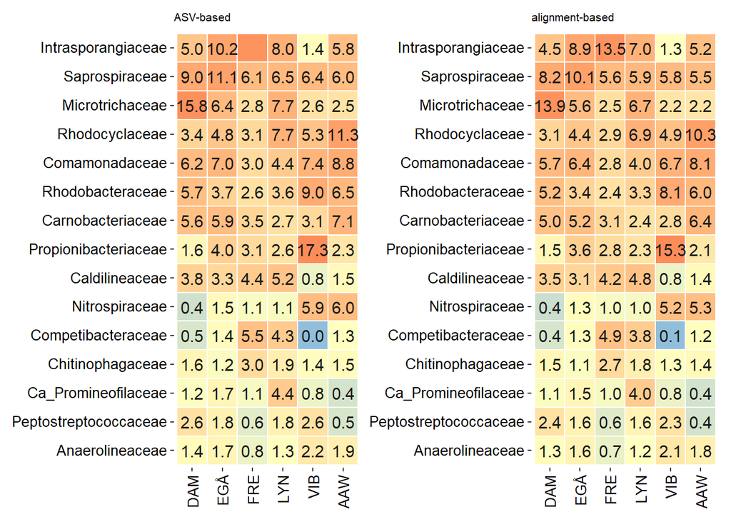

```r
amp_heatmap(d_ASV %>% amp_subset_samples(!str_detect(PlantID,  "PCR")),
            group_by = "PlantID",
            normalise = T,
            tax_show = 15,
            tax_aggregate = "Family")+
      labs(subtitle = "ASV-based") +   theme(axis.text.y = element_text(size = 10)) +
  amp_heatmap(d_alignment_norm %>% amp_subset_samples(!str_detect(PlantID,  "PCR")),
                 group_by = "PlantID",
              normalise = F,
              tax_show = 15,
              tax_aggregate = "Family") +
        labs(subtitle = "alignment-based")  + theme(axis.text.y = element_text(size = 10))
```

# Consider how to merge dataset to visualize betadiversity

–> no match between the ASVs –> Aggregate at higher taxonomic rank e.g. Species or Genus

*Install the vegan package*

## Species

```r
make_df <- long_data_merged %>%
  group_by(Species, Barcode, type, PlantID) %>%
  summarise(rel_abun = sum(count)) %>%
  ungroup() %>%
  mutate(Species = if_else(Species == "", "Unclassified", Species)) %>%
  filter(Species != "Unclassified")  %>%     ## Remove unclassified taxa
  select(Barcode, type, PlantID,Species, rel_abun) %>%
  mutate(SampleID = paste0(type, "_", Barcode)) %>% relocate(SampleID) %>%
  filter(rel_abun > 0.001)
```

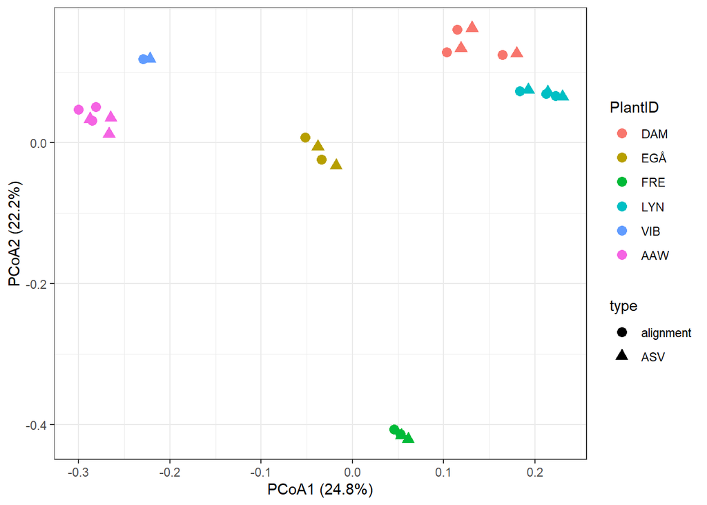

```r
# Format as matrix
species_mat <- make_df %>%
  pivot_wider(
    names_from = Species,
    values_from = rel_abun,
    values_fill = 0
  )

# Metadata
metadata <- species_mat %>%
  select(SampleID, type, PlantID)

comm <- species_mat %>%
  select(-SampleID, -Barcode, -type, -PlantID) %>%
  mutate(across(everything(), as.numeric)) %>%
  as.data.frame()

rownames(comm) <- metadata$SampleID

# Calculate distance matrix
bc_dist <- vegan::vegdist(comm, method = "bray")


# PCoA
pcoa <- cmdscale(bc_dist, eig = TRUE, k = 2)

pcoa_df <- data.frame(
  SampleID = rownames(comm),
  Axis1 = pcoa$points[,1],
  Axis2 = pcoa$points[,2]
) %>%
  left_join(metadata, by = "SampleID")

# Variance explained
var_exp <- round(100 * pcoa$eig / sum(pcoa$eig[pcoa$eig > 0]), 1)

# Plot
ggplot(
  pcoa_df,
  aes(
    x = Axis1,
    y = Axis2,
    color = PlantID,
    shape = type
  )
) +
  geom_point(size = 3) +
  labs(
    x = paste0("PCoA1 (", var_exp[1], "%)"),
    y = paste0("PCoA2 (", var_exp[2], "%)")
  ) +
  theme_bw()
```

## Species - one plant

```r
make_df <- long_data_merged %>%
  filter(PlantID == "AAW") %>%
  group_by(Species, Barcode, type, PlantID) %>%
  summarise(rel_abun = sum(count)) %>%
  ungroup() %>%
  mutate(Species = if_else(Species == "", "Unclassified", Species)) %>%
  filter(Species != "Unclassified")  %>%     ## Remove unclassified taxa
  select(Barcode, type, PlantID,Species, rel_abun) %>%
  mutate(SampleID = paste0(type, "_", Barcode)) %>% relocate(SampleID) %>%
  filter(rel_abun > 0.01)
```

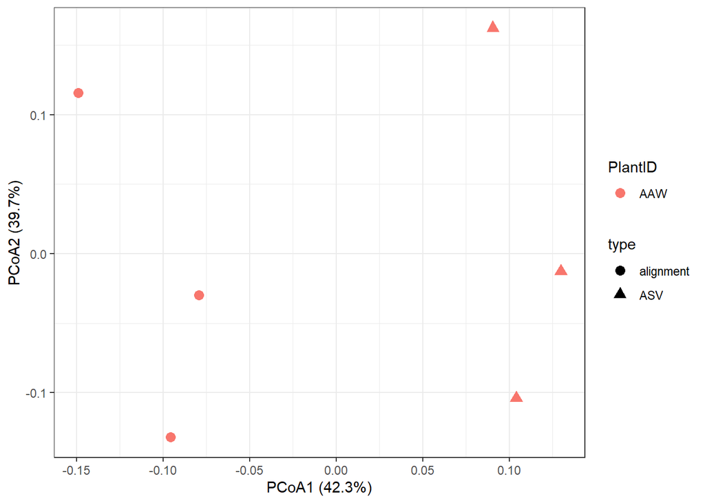

```r
# Format as matrix
species_mat <- make_df %>%
  pivot_wider(
    names_from = Species,
    values_from = rel_abun,
    values_fill = 0
  )

# Metadata
metadata <- species_mat %>%
  select(SampleID, type, PlantID)

comm <- species_mat %>%
  select(-SampleID, -Barcode, -type, -PlantID) %>%
  mutate(across(everything(), as.numeric)) %>%
  as.data.frame()

rownames(comm) <- metadata$SampleID

# Calculate distance matrix
bc_dist <- vegan::vegdist(comm, method = "bray")


# PCoA
pcoa <- cmdscale(bc_dist, eig = TRUE, k = 2)

pcoa_df <- data.frame(
  SampleID = rownames(comm),
  Axis1 = pcoa$points[,1],
  Axis2 = pcoa$points[,2]
) %>%
  left_join(metadata, by = "SampleID")

# Variance explained
var_exp <- round(100 * pcoa$eig / sum(pcoa$eig[pcoa$eig > 0]), 1)

# Plot
ggplot(
  pcoa_df,
  aes(
    x = Axis1,
    y = Axis2,
    color = PlantID,
    shape = type
  )
) +
  geom_point(size = 3) +
  labs(
    x = paste0("PCoA1 (", var_exp[1], "%)"),
    y = paste0("PCoA2 (", var_exp[2], "%)")
  ) +
  theme_bw()
```

## Genus

```r
make_df <- long_data_merged %>%
  group_by(Genus, Barcode, type, PlantID) %>%
  summarise(rel_abun = sum(count)) %>%
  ungroup() %>%
  mutate(Genus = if_else(Genus == "", "Unclassified", Genus)) %>%
  filter(Genus != "Unclassified")  %>%     ## Remove unclassified taxa
  select(Barcode, type, PlantID,Genus, rel_abun) %>%
  mutate(SampleID = paste0(type, "_", Barcode)) %>% relocate(SampleID) %>%
  filter(rel_abun > 0.01)
```

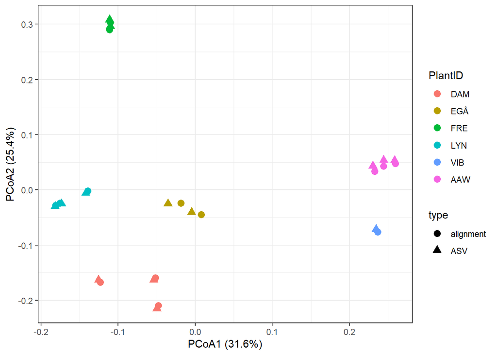

```r
# Format as matrix
species_mat <- make_df %>%
  pivot_wider(
    names_from = Genus,
    values_from = rel_abun,
    values_fill = 0
  )

# Metadata
metadata <- species_mat %>%
  select(SampleID, type, PlantID)

comm <- species_mat %>%
  select(-SampleID, -Barcode, -type, -PlantID) %>%
  mutate(across(everything(), as.numeric)) %>%
  as.data.frame()

rownames(comm) <- metadata$SampleID

# Calculate distance matrix
bc_dist <- vegan::vegdist(comm, method = "bray")


# PCoA
pcoa <- cmdscale(bc_dist, eig = TRUE, k = 2)

pcoa_df <- data.frame(
  SampleID = rownames(comm),
  Axis1 = pcoa$points[,1],
  Axis2 = pcoa$points[,2]
) %>%
  left_join(metadata, by = "SampleID")

# Variance explained
var_exp <- round(100 * pcoa$eig / sum(pcoa$eig[pcoa$eig > 0]), 1)

# Plot
ggplot(
  pcoa_df,
  aes(
    x = Axis1,
    y = Axis2,
    color = PlantID,
    shape = type
  )
) +
  geom_point(size = 3) +
  labs(
    x = paste0("PCoA1 (", var_exp[1], "%)"),
    y = paste0("PCoA2 (", var_exp[2], "%)")
  ) +
  theme_bw()
```

## Genus - one plant

```r
make_df <- long_data_merged %>%
    filter(PlantID == "AAW") %>%
  group_by(Genus, Barcode, type, PlantID) %>%
  summarise(rel_abun = sum(count)) %>%
  ungroup() %>%
  mutate(Genus = if_else(Genus == "", "Unclassified", Genus)) %>%
  filter(Genus != "Unclassified")  %>%     ## Remove unclassified taxa
  select(Barcode, type, PlantID,Genus, rel_abun) %>%
  mutate(SampleID = paste0(type, "_", Barcode)) %>% relocate(SampleID) %>%
  filter(rel_abun > 0.01)
```

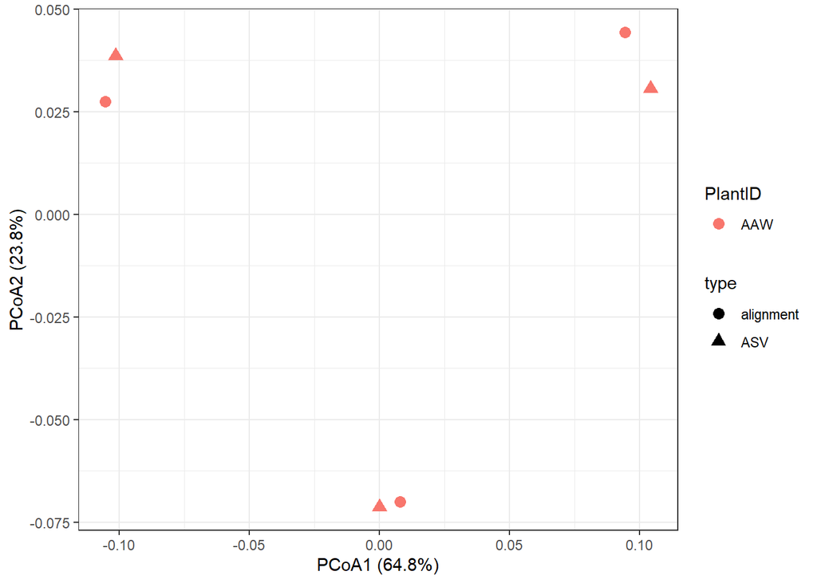

```r
# Format as matrix
species_mat <- make_df %>%
  pivot_wider(
    names_from = Genus,
    values_from = rel_abun,
    values_fill = 0
  )

# Metadata
metadata <- species_mat %>%
  select(SampleID, type, PlantID)

comm <- species_mat %>%
  select(-SampleID, -Barcode, -type, -PlantID) %>%
  mutate(across(everything(), as.numeric)) %>%
  as.data.frame()

rownames(comm) <- metadata$SampleID

# Calculate distance matrix
bc_dist <- vegan::vegdist(comm, method = "bray")


# PCoA
pcoa <- cmdscale(bc_dist, eig = TRUE, k = 2)

pcoa_df <- data.frame(
  SampleID = rownames(comm),
  Axis1 = pcoa$points[,1],
  Axis2 = pcoa$points[,2]
) %>%
  left_join(metadata, by = "SampleID")

# Variance explained
var_exp <- round(100 * pcoa$eig / sum(pcoa$eig[pcoa$eig > 0]), 1)

# Plot
ggplot(
  pcoa_df,
  aes(
    x = Axis1,
    y = Axis2,
    color = PlantID,
    shape = type
  )
) +
  geom_point(size = 3) +
  labs(
    x = paste0("PCoA1 (", var_exp[1], "%)"),
    y = paste0("PCoA2 (", var_exp[2], "%)")
  ) +
  theme_bw()
```

# At which taxonomic level would you trust the datasets? Why?